# Data-visualisation-matplotlib

## Get the Data

Either use the provided .csv file or (optionally) get fresh (the freshest?) data from running an SQL query on StackExchange:

Follow this link to run the query from [StackExchange](https://data.stackexchange.com/stackoverflow/query/675441/popular-programming-languages-per-over-time-eversql-com) to get your own .csv file

```
select dateadd(month, datediff(month, 0, q.CreationDate), 0) m, TagName, count(*)
from PostTags pt
join Posts q on q.Id=pt.PostId
join Tags t on t.Id=pt.TagId
where TagName in ('java','c','c++','python','c#','javascript','assembly','php','perl','ruby','visual basic','swift','r','object-c','scratch','go','swift','delphi')
and q.CreationDate < dateadd(month, datediff(month, 0, getdate()), 0)
group by dateadd(month, datediff(month, 0, q.CreationDate), 0), TagName
order by dateadd(month, datediff(month, 0, q.CreationDate), 0)
```

## Import Statements

```python
import pandas as pd
```

## Data Exploration

**Challenge**: Read the .csv file and store it in a Pandas dataframe

```python
df = pd.read_csv('QueryResults.csv', names=['DATE', 'TAG', 'POSTS'], header=0)
```

**Challenge**: Examine the first 5 rows and the last 5 rows of the of the dataframe

```python
df.head()
```

|  | DATE | TAG | POSTS |
| --- | --- | --- | --- |
| 0 | 2008-07-01 00:00:00 | c# | 3 |
| 1 | 2008-08-01 00:00:00 | assembly | 8 |
| 2 | 2008-08-01 00:00:00 | c | 83 |
| 3 | 2008-08-01 00:00:00 | c# | 505 |
| 4 | 2008-08-01 00:00:00 | c++ | 164 |

```python
df.tail()
```

|  | DATE | TAG | POSTS |
| --- | --- | --- | --- |
| 2449 | 2023-04-01 00:00:00 | php | 2132 |
| 2450 | 2023-04-01 00:00:00 | python | 13085 |
| 2451 | 2023-04-01 00:00:00 | r | 3176 |
| 2452 | 2023-04-01 00:00:00 | ruby | 225 |
| 2453 | 2023-04-01 00:00:00 | swift | 1149 |

**Challenge:** Check how many rows and how many columns there are. What are the dimensions of the dataframe?

```python
df.shape
```

```
(2454, 3)
```

**Challenge**: Count the number of entries in each column of the dataframe

```python
df.count()
```

```
DATE     2454
TAG      2454
POSTS    2454
dtype: int64
```

**Challenge**: Calculate the total number of post per language. Which Programming language has had the highest total number of posts of all time?

```python
df.groupby('TAG').sum()
```

| TAG | POSTS |
| --- | --- |
| assembly | 42619 |
| c | 395503 |
| c# | 1588527 |
| c++ | 792355 |
| delphi | 50814 |
| go | 68796 |
| java | 1893550 |
| javascript | 2488492 |
| perl | 67617 |
| php | 1456715 |
| python | 2126356 |
| r | 487791 |
| ruby | 227707 |
| swift | 326407 |

**Challenge**: How many months of data exist per language? Which language had the fewest months with an entry?

```python
df.groupby('TAG').count()
```

| TAG | DATE | POSTS |
| --- | --- | --- |
| assembly | 177 | 177 |
| c | 177 | 177 |
| c# | 178 | 178 |
| c++ | 177 | 177 |
| delphi | 177 | 177 |
| go | 162 | 162 |
| java | 177 | 177 |
| javascript | 177 | 177 |
| perl | 177 | 177 |
| php | 177 | 177 |
| python | 177 | 177 |
| r | 175 | 175 |
| ruby | 177 | 177 |
| swift | 169 | 169 |

## Data Cleaning

Let's fix the date format to make it more readable. We need to use Pandas to change format from a string of "2008-07-01 00:00:00" to a datetime object with the format of "2008-07-01"

```python
df.DATE[0]
```

```
'2008-07-01 00:00:00'
```

```python
pd.to_datetime(df.DATE[0])
```

```
Timestamp('2008-07-01 00:00:00')
```

```python
df.DATE = pd.to_datetime(df.DATE)
df.head()
```

|  | DATE | TAG | POSTS |
| --- | --- | --- | --- |
| 0 | 2008-07-01 | c# | 3 |
| 1 | 2008-08-01 | assembly | 8 |
| 2 | 2008-08-01 | c | 83 |
| 3 | 2008-08-01 | c# | 505 |
| 4 | 2008-08-01 | c++ | 164 |

## Data Manipulation

```python
pivoted_df = df.pivot(index='DATE', columns='TAG', values='POSTS')
pivoted_df
```

| TAG DATE | assembly | c | c# | c++ | delphi | go | java | javascript | perl | php | python | r | ruby | swift |
| --- | --- | --- | --- | --- | --- | --- | --- | --- | --- | --- | --- | --- | --- | --- |
| 2008-07-01 | NaN | NaN | 3.0 | NaN | NaN | NaN | NaN | NaN | NaN | NaN | NaN | NaN | NaN | NaN |
| 2008-08-01 | 8.0 | 83.0 | 505.0 | 164.0 | 14.0 | NaN | 222.0 | 163.0 | 28.0 | 158.0 | 120.0 | NaN | 70.0 | NaN |
| 2008-09-01 | 28.0 | 319.0 | 1641.0 | 754.0 | 104.0 | NaN | 1129.0 | 634.0 | 130.0 | 475.0 | 536.0 | 6.0 | 287.0 | NaN |
| 2008-10-01 | 16.0 | 302.0 | 1988.0 | 807.0 | 112.0 | NaN | 1149.0 | 722.0 | 128.0 | 610.0 | 506.0 | NaN | 247.0 | NaN |
| 2008-11-01 | 16.0 | 258.0 | 1731.0 | 734.0 | 141.0 | NaN | 956.0 | 580.0 | 97.0 | 499.0 | 449.0 | 1.0 | 157.0 | NaN |
| ... | ... | ... | ... | ... | ... | ... | ... | ... | ... | ... | ... | ... | ... | ... |
| 2022-12-01 | 283.0 | 1856.0 | 5326.0 | 2860.0 | 86.0 | 628.0 | 5964.0 | 12517.0 | 95.0 | 2886.0 | 19296.0 | 3683.0 | 394.0 | 1468.0 |
| 2023-01-01 | 238.0 | 1514.0 | 5372.0 | 2658.0 | 114.0 | 734.0 | 5769.0 | 12249.0 | 75.0 | 3078.0 | 18058.0 | 3754.0 | 373.0 | 1444.0 |
| 2023-02-01 | 189.0 | 1314.0 | 4774.0 | 2226.0 | 134.0 | 661.0 | 5202.0 | 10471.0 | 79.0 | 2442.0 | 15756.0 | 3809.0 | 340.0 | 1299.0 |
| 2023-03-01 | 181.0 | 1268.0 | 4929.0 | 2584.0 | 142.0 | 641.0 | 5567.0 | 10593.0 | 96.0 | 2290.0 | 15637.0 | 3842.0 | 304.0 | 1377.0 |
| 2023-04-01 | 202.0 | 1227.0 | 3985.0 | 2060.0 | 124.0 | 544.0 | 4706.0 | 8659.0 | 58.0 | 2132.0 | 13085.0 | 3176.0 | 225.0 | 1149.0 |

178 rows × 14 columns

**Challenge**: What are the dimensions of our new dataframe? How many rows and columns does it have? Print out the column names and print out the first 5 rows of the dataframe.

```python
pivoted_df.shape
```

```
(178, 14)
```

```python
pivoted_df.columns
```

```
Index(['assembly', 'c', 'c#', 'c++', 'delphi', 'go', 'java', 'javascript',
       'perl', 'php', 'python', 'r', 'ruby', 'swift'],
      dtype='object', name='TAG')
```

```python
pivoted_df.head()
```

| TAG DATE | assembly | c | c# | c++ | delphi | go | java | javascript | perl | php | python | r | ruby | swift |
| --- | --- | --- | --- | --- | --- | --- | --- | --- | --- | --- | --- | --- | --- | --- |
| 2008-07-01 | NaN | NaN | 3.0 | NaN | NaN | NaN | NaN | NaN | NaN | NaN | NaN | NaN | NaN | NaN |
| 2008-08-01 | 8.0 | 83.0 | 505.0 | 164.0 | 14.0 | NaN | 222.0 | 163.0 | 28.0 | 158.0 | 120.0 | NaN | 70.0 | NaN |
| 2008-09-01 | 28.0 | 319.0 | 1641.0 | 754.0 | 104.0 | NaN | 1129.0 | 634.0 | 130.0 | 475.0 | 536.0 | 6.0 | 287.0 | NaN |
| 2008-10-01 | 16.0 | 302.0 | 1988.0 | 807.0 | 112.0 | NaN | 1149.0 | 722.0 | 128.0 | 610.0 | 506.0 | NaN | 247.0 | NaN |
| 2008-11-01 | 16.0 | 258.0 | 1731.0 | 734.0 | 141.0 | NaN | 956.0 | 580.0 | 97.0 | 499.0 | 449.0 | 1.0 | 157.0 | NaN |

**Challenge**: Count the number of entries per programming language. Why might the number of entries be different?

```python
pivoted_df.count()
```

```
TAG
assembly      177
c             177
c#            178
c++           177
delphi        177
go            162
java          177
javascript    177
perl          177
php           177
python        177
r             175
ruby          177
swift         169
dtype: int64
```

```python
pivoted_df.fillna(0, inplace = True)
```

```python
pivoted_df.isna().values.any()
```

```
False
```

## Data Visualisaton with with Matplotlib

**Challenge**: Use the [matplotlib documentation](https://matplotlib.org/3.2.1/api/_as_gen/matplotlib.pyplot.plot.html#matplotlib.pyplot.plot) to plot a single programming language (e.g., java) on a chart.

```python
import matplotlib.pyplot as plt
```

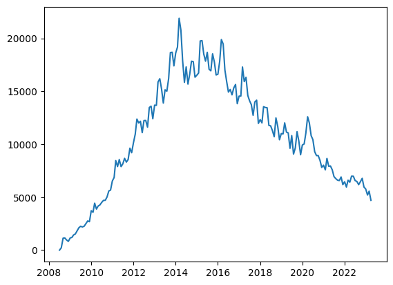

```python
plt.plot(pivoted_df.index, pivoted_df.java)
```

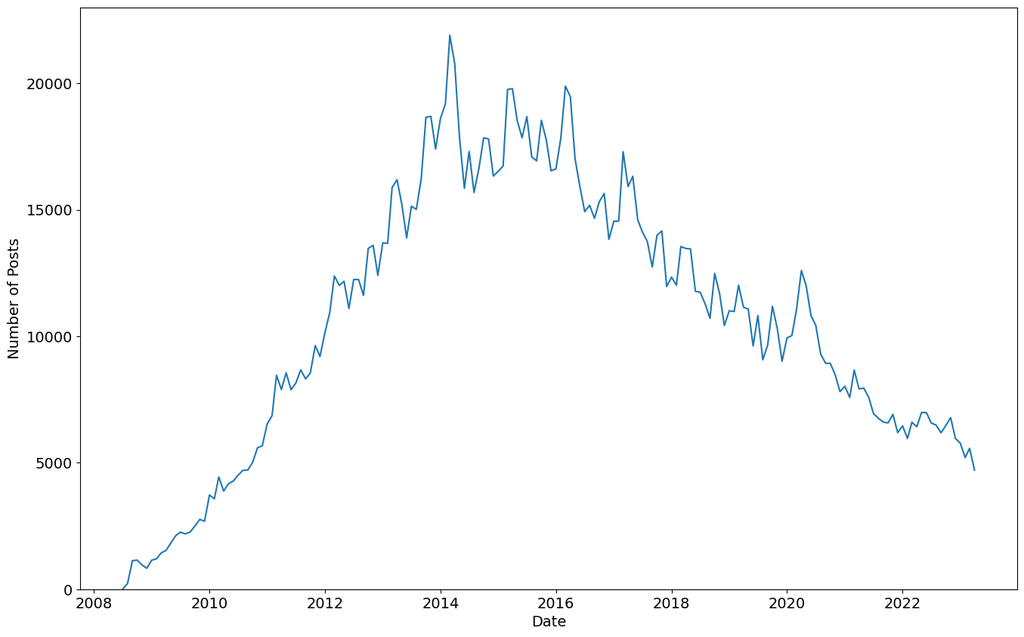

```python
plt.figure(figsize = (16,10))
plt.yticks(fontsize = 14)
plt.xticks(fontsize = 14)
plt.xlabel('Date', fontsize=14)
plt.ylabel('Number of Posts', fontsize=14)
plt.ylim(0, 23000)
plt.plot(pivoted_df.index, pivoted_df.java)
```

**Challenge**: Show two line (e.g. for Java and Python) on the same chart.

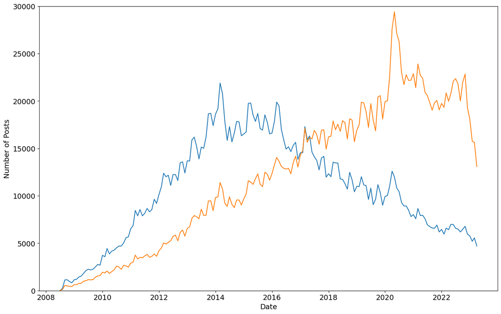

```python
plt.figure(figsize = (16,10))
plt.yticks(fontsize = 14)
plt.xticks(fontsize = 14)
plt.xlabel('Date', fontsize=14)
plt.ylabel('Number of Posts', fontsize=14)
plt.ylim(0, 30000)
plt.plot(pivoted_df.index, pivoted_df.java)
plt.plot(pivoted_df.index, pivoted_df.python)
```

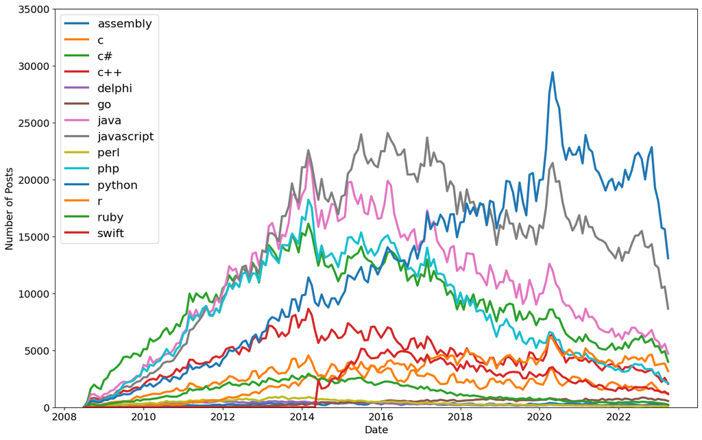

```python
plt.figure(figsize=(16,10))
plt.xticks(fontsize=14)
plt.yticks(fontsize=14)
plt.xlabel('Date', fontsize=14)
plt.ylabel('Number of Posts', fontsize=14)
plt.ylim(0, 35000)

for column in pivoted_df.columns:
  plt.plot(pivoted_df.index, pivoted_df[column],
           linewidth=3, label = pivoted_df[column].name)

plt.legend(fontsize=16)
```

# Smoothing out Time Series Data

Time series data can be quite noisy, with a lot of up and down spikes. To better see a trend we can plot an average of, say 6 or 12 observations. This is called the rolling mean. We calculate the average in a window of time and move it forward by one overservation. Pandas has two handy methods already built in to work this out: [rolling()](https://pandas.pydata.org/pandas-docs/stable/reference/api/pandas.DataFrame.rolling.html) and [mean()](https://pandas.pydata.org/pandas-docs/stable/reference/api/pandas.core.window.rolling.Rolling.mean.html).

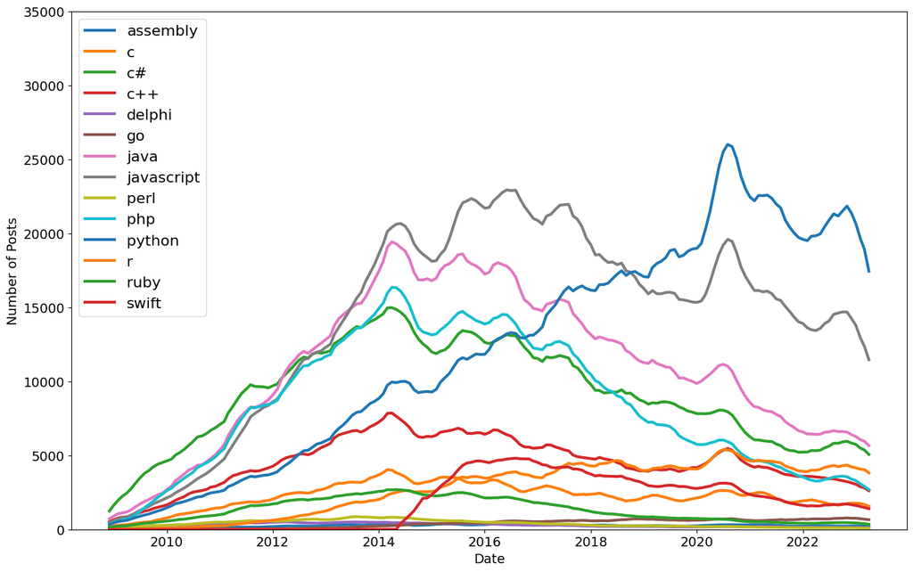

```python
roll_df = pivoted_df.rolling(window = 6).mean()

plt.figure(figsize=(16,10))
plt.xticks(fontsize=14)
plt.yticks(fontsize=14)
plt.xlabel('Date', fontsize=14)
plt.ylabel('Number of Posts', fontsize=14)
plt.ylim(0, 35000)

# plot the roll_df instead
for column in roll_df.columns:
    plt.plot(roll_df.index, roll_df[column],
             linewidth=3, label=roll_df[column].name)

plt.legend(fontsize=16)
```